# Noche y Niebla Project

After extracting raw data from Noche y Niebla magazine query system and storing it(row=crime, col=feat), we pre-process it for classification, create additional columns, and explore its content.

```python
df = pickle.load(open("df_fin.p", "rb")) # scarped data stored in pd dataframe
df['mnth_yr'] = pd.to_datetime(df['mnth_yr'])
df['mnth_yr'] = df['mnth_yr'].dt.date
```

39,363 observations from Jan 1990 to Feb 2018 (Note: 1 or more victims per case):

```python
df.shape
```

```
(39363, 14)
```

### Text Pre-processing

```python
def no_tilde(x):
    tilds = ['á', 'é', 'í' ,'ó' ,'ú', '"', ',', '.']
    new = ['a', 'e', 'i','o','u', '', '', '']
    for i, t in enumerate(tilds):
        if t in x:
            x = x.replace(t, new[i])
    return x
```

```python
def stem(x):
    wlist =  [SnowballStemmer("spanish").stem(w) for w in x.split()]
    return ' '.join(word for word in wlist)
```

```python
user_defined_stop_words = ['a', 'ante', 'con', 'de','por','si', 'la', 'en' , 'el', 'que', 'del', 'los' , 'y',
                           'las', 'para', 'uno', 'una', 'unos', 'como', 'los', 'fue', 'al', 'su', 'se', 'un',
                           'lo','no', 'e', 'mi', 'es', 'me', 'era', 'le', 'sus', 'su', 'hasta', 'sin', 'o', 'u',\
                           'ha', 'han', 'y']
stopwords = list(string.punctuation) + user_defined_stop_words

def clean_desc(x, stopwords):
    words = x.split()
    new_words = [word for word in words if word not in stopwords]
    return ' '.join(word.lower() for word in new_words)
```

Descriptions without tilde to make text analysis simpler:

```python
df['Description'] = df['Description'].apply(no_tilde) # no tildes
```

Remove stop words and turn all text into lower case:

```python
df['Description_clean'] = df['Description'].apply(clean_desc, args =(stopwords,))
```

Stem words from their root:

```python
df['Description_clean']= df['Description_clean'].apply(stem)
```

## I. Exploration

```python
def graph_by_year(df, title, factor):
    colors = plt.cm.GnBu(np.linspace(0, 1, len(df[factor].unique())))
    df_gmth = pd.DataFrame({'Count' : df.groupby(['year', factor]).size()}).reset_index()
    df_gmth = df_gmth[df_gmth.Count >=0]
    df_gmth_piv = df_gmth.pivot(index='year', columns=factor, values='Count')
    df_gmth_piv.plot(kind='bar', stacked=True, color = colors)
    plt.legend(bbox_to_anchor=(1.05, 1), loc=2, borderaxespad=0.)
    plt.title(title)
```

```python
def monthly_ts(df, title):
    df_gmth = pd.DataFrame({'Count' : df.groupby(['mnth_yr']).size()}).reset_index()
    ax = df_gmth.plot(legend=False)
    #plt.legend(bbox_to_anchor=(1.05, 1), loc=2, borderaxespad=0.)
    plt.title(title)
```

```python
def plot_by_cont_filter(df, factor, word, title):
    '''
    Inputs:
    - df (pd.DataFrame)
    - factor (col)
    - words (list)
    - title (str)
    '''

    df_gmth = pd.DataFrame({'Count' : df.groupby(['mnth_yr']).size()}).reset_index()
    df_int = pd.DataFrame({'Dum': df[factor].str.contains(word), 'mnth_yr': df['mnth_yr']})
    df_intc = df_int.groupby(['mnth_yr']).sum().reset_index()
    df_gmth['int'] = df_intc.Dum
    df_gmth['int_rat'] = df_gmth['int'] / df_gmth['Count']
    ax = df_gmth.int_rat.plot()
    plt.title(title)
    return df_gmth
```

```python
def graph_by_per(df, title, factor, per='year'):
    s = df.groupby(per)[factor].sum()
    s.plot()
    plt.title(title)
```

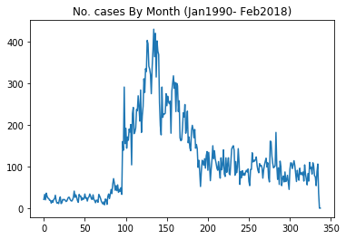

```python
monthly_ts(df, 'No. cases By Month (Jan1990- Feb2018)')
```

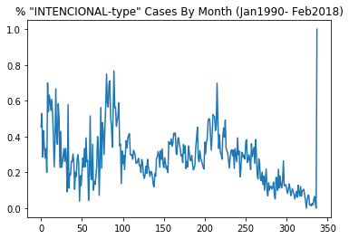

```python
dm = plot_by_cont_filter(df, 'Type', 'INTENCIONAL', '% "INTENCIONAL-type" Cases By Month (Jan1990- Feb2018)')
```

Note: there is only one observation for Feb2018, and it is classified as intentional in the Type field, hence the "spike".

## II. Classification (word frequency analysis)

Conditional probability based on word frequencies relative to the whole "vocabulary" (i.e. the set of all words in the descriptions) and Bayes Rule.  
**Goal**: obtain the words that are strongly predictive of label 'INTENTIONAL':

```python
#nb2 = MultinomialNB(alpha=1, fit_prior=False)
#nb2.fit(X_train, Y_train)
#preds2 = nb1.predict(X_test)
```

```python
#count_vect.get_feature_names()
#nb2.classes_
#top50 = sorted(zip(nb2.coef_[0], count_vect.get_feature_names()))[-50:]
```

```python
top50
```

```
[(-5.926192827254556, 'arma'),
 (-5.9150195266564305, 'pm'),
 (-5.899752054525642, 'dieron'),
 (-5.888868732368249, 'farcep'),
 (-5.88803643935308, 'era'),
 (-5.872353080337528, 'ubic'),
 (-5.867451109737321, 'da'),
 (-5.848879724151886, 'correg'),
 (-5.795149401730918, 'fuent'),
 (-5.788349224411854, 'este'),
 (-5.783841327972664, 'lueg'),
 (-5.782343200351642, 'miembr'),
 (-5.771918683015757, 'hombr'),
 (-5.734837008111226, 'cas'),
 (-5.706685958448711, 'cuand'),
 (-5.6990813590634914, 'dond'),
 (-5.697017374842639, 'qui'),
 (-5.696330325691601, 'polic'),
 (-5.690850859926976, 'tres'),
 (-5.664560164695258, 'zon'),
 (-5.6158650530424135, 'edad'),
 (-5.589597126221803, 'present'),
 (-5.584671007885747, 'barri'),
 (-5.56039797152954, 'nacional'),
 (-5.543750738096384, 'encontr'),
 (-5.523323999272024, 'impact'),
 (-5.486461305586087, 'haci'),
 (-5.484236610563976, 'asesin'),
 (-5.47153977976957, 'sus'),
 (-5.45037209661122, 'comun'),
 (-5.419698089426405, 'ejrcit'),
 (-5.415540079277742, 'fueron'),
 (-5.389431608845667, 'le'),
 (-5.382884116303689, 'grup'),
 (-5.3522341639597295, 'vari'),
 (-5.3206071867821745, 'vctim'),
 (-5.27271589907776, 'municipi'),
 (-5.266887592958103, 'hab'),
 (-5.263317754271878, 'denunci'),
 (-5.207025837979491, 'segn'),
 (-5.1138231405147305, 'aos'),
 (-5.094825608688419, 'campesin'),
 (-5.070289061774473, 'guerriller'),
 (-5.018757088564863, 'dos'),
 (-5.001810461319684, 'muert'),
 (-4.996338491441691, 'vered'),
 (-4.9767498880635, 'person'),
 (-4.8382975129908115, 'hech'),
 (-4.403562022582534, 'ejecut'),
 (-4.302339013889899, 'paramilitar')]
```